# Coursera Practical Machine Learning Project

Omar Mohamed

2019 M09 4

#### **Download Traning Dataset and Testing Dataset**

```r
Training.Url <- "https://d396qusza40orc.cloudfront.net/predmachlearn/pml-training.csv"
Testing.Url <-  "https://d396qusza40orc.cloudfront.net/predmachlearn/pml-testing.csv"

if(!file.exists("Data")){
  dir.create("Data")
  download.file(Training.Url , destfile = "./Data/pml_training.csv")
  download.file(Testing.Url , destfile = "./Data/pml_testing.csv")
}

list.files("./Data")
```

```
## [1] "pml_testing.csv"  "pml_training.csv"
```

#### **Data Exploration**

```r
training.data <- read.csv("./Data/pml_training.csv")
testing.data <- read.csv("./Data/pml_testing.csv")
```

look at the dimensions of two dataset

```r
sprintf("training data has %i rows and %i columns",dim(training.data)[1],dim(training.data)[2])
```

```
## [1] "training data has 19622 rows and 160 columns"
```

```r
sprintf("testing data has %i rows and %i columns",dim(testing.data)[1],dim(testing.data)[2])
```

```
## [1] "testing data has 20 rows and 160 columns"
```

checking missing values and remove them

```r
any(is.na(training.data))
```

```
## [1] TRUE
```

removing columns which has more than 10000 NA values

```r
remove.cols <- which(colSums(is.na(training.data))>10000)
training.data <- training.data[,-remove.cols]
```

removing columns which has more than 10000 empty values

```r
training.data <- training.data[,-c(which(colSums(training.data=="")>10000))]
```

Also remove all time related data, and ignore username and windows columns since we won’t use those

```r
removeColumns <- grep("timestamp", names(training.data))
training.data <- training.data[,-c(1, removeColumns )]
training.data <- training.data[,-c(1:3)]
```

#### **Build Model**

We already read a testing dataset so, we considered it as a validation dataset , Now split the training data into training set and testing set

```r
set.seed(1234)
library("caret")
inTrain <- createDataPartition(y = training.data$classe , p = 0.7 , list = FALSE)
train.subset <- training.data[inTrain,]
test.subset <- training.data[-inTrain,]
```

#### **Model Training**

first parallel processing in **caret** can be accomplished with **doParallel** package but before load it you must load **foreach** and **iterators** packages then train the model with **random forest**

we save model in rds file so, when can read the model

i comment the line of train fn because it take too much time

```r
library("doParallel")
cluster <- makeCluster(detectCores() -1)
registerDoParallel(cluster)

#set.seed(110054)
#model <- train(classe~. , data = train.subset , method="rf" , preProcess = c('center', 'scale'))
#save.model <- saveRDS(model , file = 'RF.rds')
model <- readRDS("RF.rds")
```

#### **Prediction on Train data**

```r
pred<- predict(model , test.subset)
confusionMatrix(pred , test.subset$classe)$overall[1]
```

```
##  Accuracy
## 0.9942226
```

print results

```r
table(pred)
```

```
## pred
##    A    B    C    D    E
## 1686 1132 1026  963 1078
```

#### **Variable Importance**

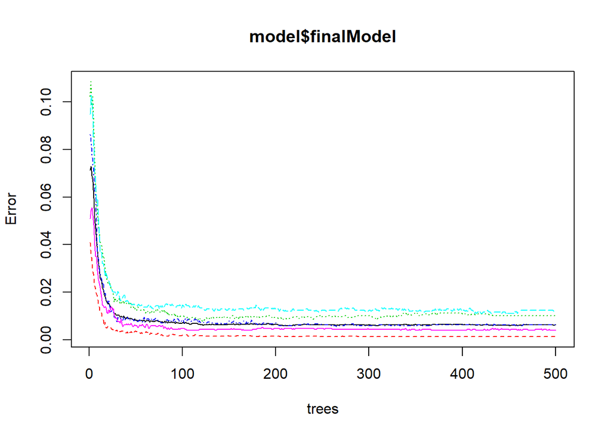

```r
plot(model$finalModel)
```

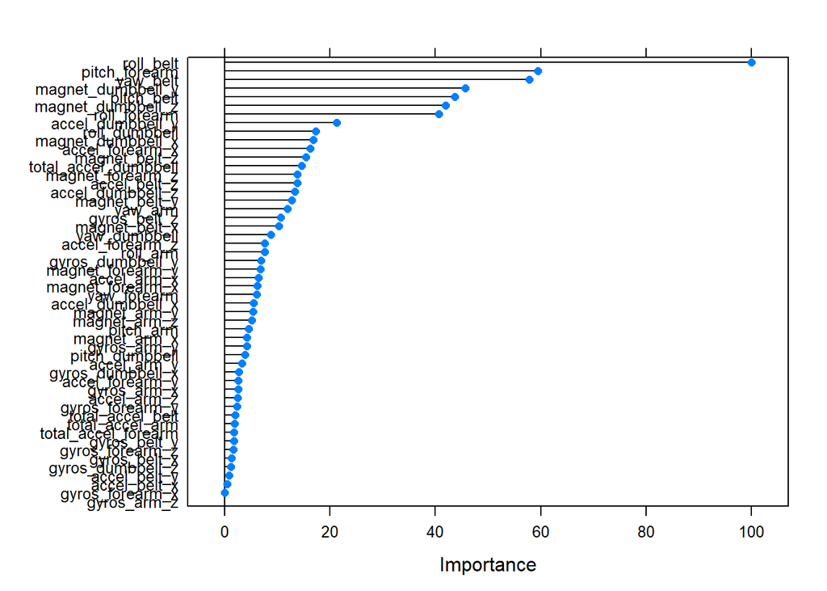

```r
plot(varImp(model) , maint = "Random Forest")
```

#### **Using the test data**

check for NA values

```r
any(is.na(testing.data))
```

```
## [1] TRUE
```

remove columns which has more than 15 NA values

```r
testing.data <- testing.data[,-c(which(colSums(is.na(testing.data))>15))]
```

Also remove all time related data, and ignore username and windows columns since we won’t use those

```r
removeColumns <- grep("timestamp", names(testing.data))
testing.data <- testing.data[,-c(1, removeColumns )]
testing.data <- testing.data[,-c(1:3)]
```

#### **Prediction on Testing data**

```r
pred2 <- predict(model , testing.data)
table(pred2)
```

```
## pred2
## A B C D E
## 7 8 1 1 3
```